# Model Evaluation

Shiwani Sapkota

2023-04-07

LOADING REQUIRED PACKAGES

```r
# Loading required packages
library(readr)
library(tidyverse)
library(dplyr)
library(gtsummary)
library(ggplot2)
library(ggthemes)
library(here)
library(tidymodels)
library(performance)
library(vip)
library(broom)
library(gridExtra)
library(cowplot)
```

LOADING AND LOOKING AT THE DATA

```r
# Reading the cleaned rds file
data_clean <- readRDS(here("data", "processed_cleaned_data", "mammogram_ses_clean.rds"))
glimpse(data_clean)
```

```
## Rows: 24,848
## Columns: 19
## $ year                     <dbl> 2000, 2000, 2000, 2000, 2000, 2000, 2000, 200…
## $ sex                      <int+lbl> 2, 2, 2, 2, 2, 2, 2, 2, 2, 2, 2, 2, 2, 2,…
## $ age                      <dbl+lbl> 6, 3, 3, 1, 2, 5, 4, 2, 1, 3, 1, 2, 3, 1,…
## $ hispanic_status          <int+lbl> 2, 1, 1, 1, 1, 1, 1, 1, 1, 1, 1, 1, 2, 1,…
## $ income                   <int+lbl> 1, 2, 1, 1, 1, 1, 1, 1, 1, 1, 1, 1, 1, 1,…
## $ education                <int+lbl> 2, 5, 3, 5, 4, 3, 3, 4, 5, 3, 4, 5, 3, 5,…
## $ marital_status           <int+lbl> 1, 0, 1, 1, 1, 1, 1, 0, 1, 1, 1, 1, 1, 1,…
## $ region_residence         <int+lbl> 1, 4, 4, 1, 1, 1, 2, 2, 2, 1, 1, 1, 1, 1,…
## $ insurance_status         <int+lbl> 0, 0, 0, 0, 0, 0, 0, 0, 1, 0, 0, 0, 0, 0,…
## $ privateinsurance_status  <int+lbl> 1, 1, 2, 2, 2, 2, 2, 2, 1, 2, 2, 2, 2, 2,…
## $ medicaid_status          <int+lbl> 1, 2, 1, 1, 1, 1, 1, 1, 1, 1, 1, 1, 1, 1,…
## $ medicare_status          <int+lbl> 2, 2, 1, 1, 1, 1, 1, 1, 1, 1, 1, 1, 1, 1,…
## $ health_status            <int+lbl> 1, 1, 1, 1, 1, 1, 1, 1, 1, 1, 1, 1, 2, 1,…
## $ mammogram_status         <int+lbl> 0, 1, 1, 1, 1, 1, 1, 1, 1, 1, 1, 1, 1, 1,…
## $ cancer_status            <int+lbl> 0, 0, 0, 0, 0, 0, 0, 0, 0, 0, 0, 0, 0, 0,…
## $ usual_medicalcare_status <int+lbl> 1, 1, 0, 1, 1, 0, 1, 1, 1, 1, 1, 1, 1, 1,…
## $ smoking_status           <int+lbl> 0, 1, 2, 2, 2, 2, 0, 2, 0, 0, 0, 0, 0, 1,…
## $ alcohol_status           <int+lbl> 0, 1, 2, 1, 1, 1, 1, 1, 0, 1, 1, 2, 2, 1,…
## $ diabetes_status          <int+lbl> 1, 0, 0, 0, 0, 0, 0, 0, 0, 0, 0, 0, 0, 0,…
```

```r
# Creating a new object to work with for the analysis
data_clean_main <- data_clean

# Making sure there are no missing values in any variables
any(is.na(data_clean_main))
```

```
## [1] FALSE
```

```r
# Changing class of mammogram_status variable from integer to factor as we can't use mammogram_status (main outcome) as an integer while preparing recipe and training the model
class(data_clean_main$mammogram_status)
```

```
## [1] "haven_labelled" "vctrs_vctr"     "integer"
```

```r
data_clean_main$mammogram_status <- as.factor(data_clean_main$mammogram_status)
data_clean_main$year <- as.factor(data_clean_main$year)
data_clean_main$age <- as.factor(data_clean_main$age)
data_clean_main$hispanic_status <- as.factor(data_clean_main$hispanic_status)
data_clean_main$income <- as.factor(data_clean_main$income)
data_clean_main$education <- as.factor(data_clean_main$education)
data_clean_main$marital_status <- as.factor(data_clean_main$marital_status)
data_clean_main$insurance_status <- as.factor(data_clean_main$insurance_status)
data_clean_main$health_status <- as.factor(data_clean_main$health_status)
data_clean_main$usual_medicalcare_status <- as.factor(data_clean_main$usual_medicalcare_status)
data_clean_main$smoking_status <- as.factor(data_clean_main$smoking_status)
data_clean_main$alcohol_status <- as.factor(data_clean_main$alcohol_status)
data_clean_main$diabetes_status <- as.factor(data_clean_main$diabetes_status)
```

Let’s start working on improving our model fits.

MODEL EVALUATION

DATA SPLITTING

```r
# Setting seed
set.seed(123)

# Putting 3/4 of the data into the training set
data_split <- initial_split(data_clean_main, prop = 3/4)

# Creating data frames for the two sets
train_data <- training(data_split)
test_data  <- testing(data_split)
```

**FULL MODEL: CREATING RECIPE THAT FITS A LOGISTIC MODEL USING AS OUTCOME OF INTEREST AND ALL OTHER VARIABLES AS PREDICTORS**

```r
# Using mammogram status as a categorical outcome of interest and all other variables of interest as predictors
data_clean_main_rec <- recipe(mammogram_status ~ year + age + hispanic_status + income + education + marital_status + region_residence + insurance_status + health_status + usual_medicalcare_status + smoking_status + alcohol_status + diabetes_status, data = train_data)

# Fitting the logistic model
data_clean_main_mod <- logistic_reg() %>%
                     set_engine("glm")

# Modelling workflow for pairing model and recipe
data_clean_main_wflow <- workflow() %>%
  add_model(data_clean_main_mod) %>%
  add_recipe(data_clean_main_rec)
data_clean_main_wflow
```

```
## ══ Workflow ════════════════════════════════════════════════════════════════════
## Preprocessor: Recipe
## Model: logistic_reg()
##
## ── Preprocessor ────────────────────────────────────────────────────────────────
## 0 Recipe Steps
##
## ── Model ───────────────────────────────────────────────────────────────────────
## Logistic Regression Model Specification (classification)
##
## Computational engine: glm
```

```r
# Using the resulting predictors for preparing recipe and training the model
data_clean_main_fit <-
data_clean_main_wflow %>%
  fit(data = train_data)

# Pulling the fitted model object and using tidy() function for getting a tidy tibble of model coefficients
data_clean_main_fit %>%
  extract_fit_parsnip() %>%
  tidy()
```

```
## # A tibble: 28 × 5
##    term        estimate std.error statistic  p.value
##    <chr>          <dbl>     <dbl>     <dbl>    <dbl>
##  1 (Intercept) -1.63       0.264     -6.17  6.84e-10
##  2 year2005    -0.0450     0.0649    -0.694 4.88e- 1
##  3 year2010     0.263      0.0690     3.81  1.41e- 4
##  4 year2015    -0.00689    0.0646    -0.107 9.15e- 1
##  5 age2         1.09       0.0659    16.5   6.19e-61
##  6 age3         1.52       0.0754    20.2   1.98e-90
##  7 age4         1.68       0.0843    19.9   8.10e-88
##  8 age5         1.75       0.0928    18.8   6.85e-79
##  9 age6         1.50       0.0976    15.4   1.32e-53
## 10 age7         1.54       0.106     14.6   5.61e-48
## # … with 18 more rows
```

```r
# Saving the above coefficients table
table8 <- data_clean_main_fit
saveRDS(table8, file = (here("results", "statistical_analysis_result", "2_model_evaluation_result", "logistic_full_model.rds")))
```

**FULL MODEL: USING TRAINED WORKFLOW TO PREDICT**

```r
# Using the trained workflow (data_clean_main_fit) to predict with the unseen test data
predict(data_clean_main_fit, test_data)
```

```
## # A tibble: 6,212 × 1
##    .pred_class
##    <fct>
##  1 1
##  2 1
##  3 1
##  4 1
##  5 1
##  6 1
##  7 1
##  8 1
##  9 1
## 10 1
## # … with 6,202 more rows
```

```r
# Using argument() with the model plus test data for saving them together
data_clean_main_aug <-
  augment(data_clean_main_fit, test_data)

data_clean_main_aug %>%
  select(mammogram_status, .pred_0, .pred_1)
```

```
## # A tibble: 6,212 × 3
##    mammogram_status .pred_0 .pred_1
##    <fct>              <dbl>   <dbl>
##  1 0                 0.0904   0.910
##  2 1                 0.0965   0.903
##  3 1                 0.0967   0.903
##  4 1                 0.0642   0.936
##  5 1                 0.144    0.856
##  6 1                 0.0688   0.931
##  7 1                 0.164    0.836
##  8 1                 0.0927   0.907
##  9 1                 0.0688   0.931
## 10 1                 0.0527   0.947
## # … with 6,202 more rows
```

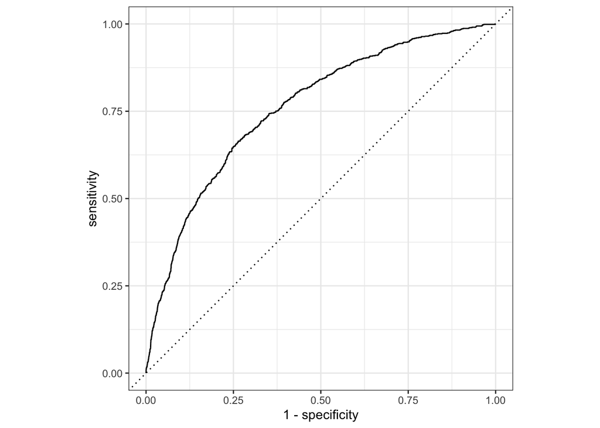

```r
# Creating ROC curve and piping to the autoplot() method
roc_fullmodel <- data_clean_main_aug %>%
  roc_curve(truth = mammogram_status, .pred_0) %>%
  autoplot()
roc_fullmodel
```

```r
# Saving the 'roc_fullmodel' figure
ggsave(filename = here("results", "statistical_analysis_result", "2_model_evaluation_result", "figure2_roc_fullmodel.png"), plot = roc_fullmodel)
# Using roc_auc() for estimating the area under the curve
data_clean_main_aug %>%
  roc_auc(truth = mammogram_status, .pred_0)
```

```
## # A tibble: 1 × 3
##   .metric .estimator .estimate
##   <chr>   <chr>          <dbl>
## 1 roc_auc binary         0.760
```

**ALTERNATIVE MODEL: USING MAMMOGRAM STATUS AS OUTCOME OF INTEREST AND HISPANIC STATUS AS MAIN PREDICTOR**

```r
# Using mammogram status as a categorical outcome of interest and hispanic status as main predictor
data_clean_main_rec2 <- recipe(mammogram_status ~ hispanic_status, data = train_data)

# Fitting the logistic model
data_clean_main_mod2 <- logistic_reg() %>%
                    set_engine("glm")

# Modelling workflow for pairing model and recipe
data_clean_main_wflow2 <- workflow() %>%
  add_model(data_clean_main_mod2) %>%
  add_recipe(data_clean_main_rec2)
data_clean_main_wflow2
```

```
## ══ Workflow ════════════════════════════════════════════════════════════════════
## Preprocessor: Recipe
## Model: logistic_reg()
##
## ── Preprocessor ────────────────────────────────────────────────────────────────
## 0 Recipe Steps
##
## ── Model ───────────────────────────────────────────────────────────────────────
## Logistic Regression Model Specification (classification)
##
## Computational engine: glm
```

```r
# Using the resulting predictors for preparing recipe and training the model
data_clean_main_fit2 <-
 data_clean_main_wflow2 %>%
  fit(data = train_data)

# Pulling the fitted model object and using tidy() function for getting a tidy tibble of model coefficients
data_clean_main_fit2 %>%
  extract_fit_parsnip() %>%
  tidy()
```

```
## # A tibble: 2 × 5
##   term             estimate std.error statistic  p.value
##   <chr>               <dbl>     <dbl>     <dbl>    <dbl>
## 1 (Intercept)         1.96     0.0242      81.0 0
## 2 hispanic_status2   -0.564    0.0527     -10.7 1.16e-26
```

```r
# Saving the above coefficients table
table9 <- data_clean_main_fit2
saveRDS(table9, file = (here("results", "statistical_analysis_result", "2_model_evaluation_result", "logistic_outcome_mainpredictor.rds")))
```

**ALTERNATIVE MODEL: USING TRAINED WORKFLOW FOR PREDICTION**

```r
# Using the trained workflow (data_clean_main_fit) to predict with the unseen test data
predict(data_clean_main_fit2, test_data)
```

```
## # A tibble: 6,212 × 1
##    .pred_class
##    <fct>
##  1 1
##  2 1
##  3 1
##  4 1
##  5 1
##  6 1
##  7 1
##  8 1
##  9 1
## 10 1
## # … with 6,202 more rows
```

```r
# Using argument() with the model plus test data for saving them together
data_clean_main_aug2 <-
  augment(data_clean_main_fit2, test_data)

data_clean_main_aug2 %>%
  select(mammogram_status, .pred_0, .pred_1)
```

```
## # A tibble: 6,212 × 3
##    mammogram_status .pred_0 .pred_1
##    <fct>              <dbl>   <dbl>
##  1 0                  0.199   0.801
##  2 1                  0.124   0.876
##  3 1                  0.124   0.876
##  4 1                  0.124   0.876
##  5 1                  0.124   0.876
##  6 1                  0.124   0.876
##  7 1                  0.124   0.876
##  8 1                  0.124   0.876
##  9 1                  0.124   0.876
## 10 1                  0.199   0.801
## # … with 6,202 more rows
```

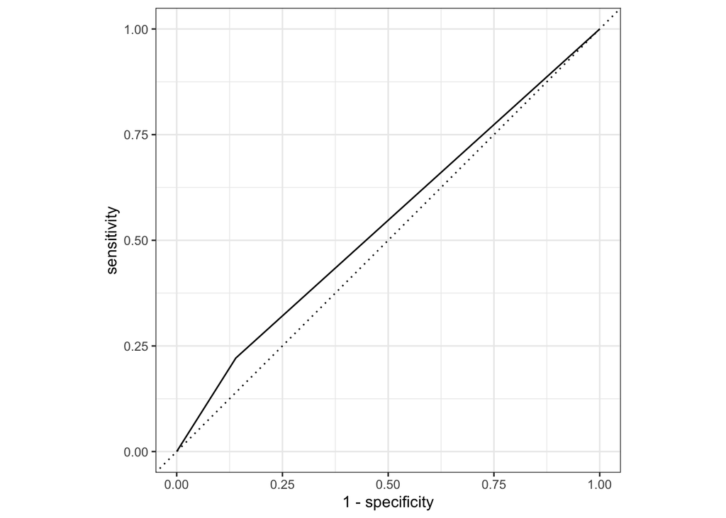

```r
# Creating ROC curve and piping to the autoplot() method
roc_altmodel <- data_clean_main_aug2 %>%
  roc_curve(truth = mammogram_status, .pred_0) %>%
  autoplot()
roc_altmodel
```

```r
# Saving the 'roc_altmodel' figure
ggsave(filename = here("results", "statistical_analysis_result", "2_model_evaluation_result", "figure3_roc_altmodel.png"), plot = roc_altmodel)
# Using roc_auc() for estimating the area under the curve
data_clean_main_aug2 %>%
  roc_auc(truth = mammogram_status, .pred_0)
```

```
## # A tibble: 1 × 3
##   .metric .estimator .estimate
##   <chr>   <chr>          <dbl>
## 1 roc_auc binary         0.541
```

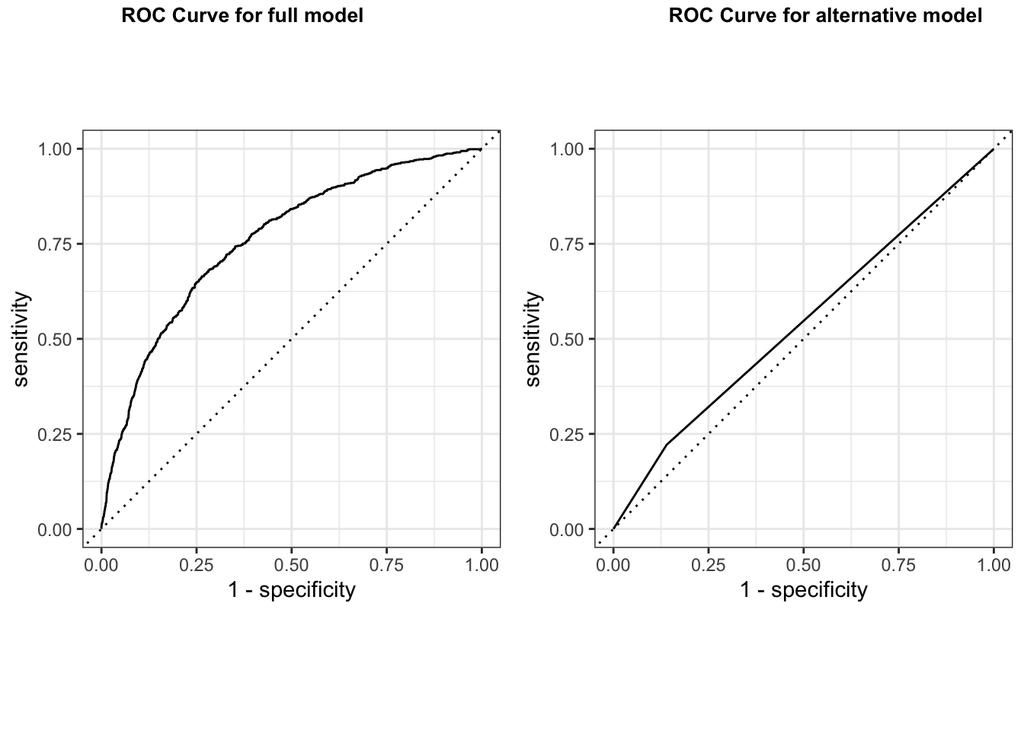

```r
# Combining and saving the above 2 ROC curves for full model and alternative model
roc_combined <- plot_grid(roc_fullmodel, roc_altmodel, ncol = 2, align = "h", axis = "tb",
                           labels = c("ROC Curve for full model", "ROC Curve for alternative model"),
                           label_size = 10)
roc_combined
```

```r
ggsave(filename = here("results", "statistical_analysis_result", "2_model_evaluation_result", "figure4_roc_combined.png"), plot = roc_combined)
```

From the above result, we see that the full model (using mammogram status as the main outcome of interest and other variables as predictors) has ROC-AUC as 0.76 while the alternative model (using mammogram status as the main outcome of interest and Hispanic status as the main predictor) has ROC-AUC as 0.54. So, we can say that for mammogram status, the full model with all the predictors of interest is better than the alternative model having only Hispanic status as the main predictor.